# WeRateDogs Project

## Analyzing and Visualizing Data

## Table of contents:

- Rating distribution
- Dog stage distribution
- Breed and prediction distribution
- Which dog stage has the highest retweets and favorite
- Source distribution
- Relation distribution between retweets and favorites

##### Before starting with my analysis I checked the 'twitter_archive_master.csv' file using .info() and changed the datatype for (source, tweet_id, timestamp). Then used .describe().

### Rating distribution

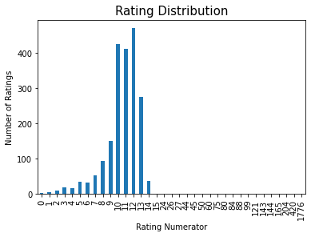

As the bar chart shows, more than 400 dogs were given a rating of 12, and the most common rating is 10, 11, and 12. Obviously the high rating shows that the users like dogs.

### Dog stage distribution

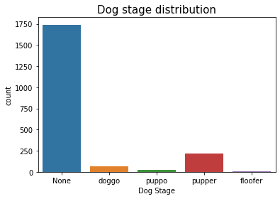

As the bar chart shows, the most common owned dog stage is pupper, the None stage might be dogs for sale. This shows that most people prefer to adopt a dog at a young age.

### Breed and prediction distribution

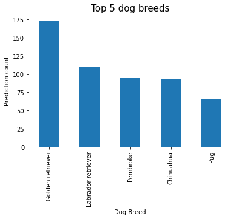

As the bar chart shows, the highset dog breed prediction is Golden retriever. Maybe this also implies that the most common dog breed is Golden retriever. Golden retrievers are know for their friendly attitude especially towards children.

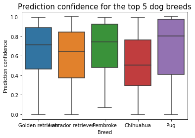

As the boxplot shows the highest confidence rate was for Pug and Pembroke, while the rest breeds were unsure like Chihuahua. Maybe this is because Pugs and Pembrokes has more distinguished features than other dogs.

### Which dog stage has the highest retweets and favorite

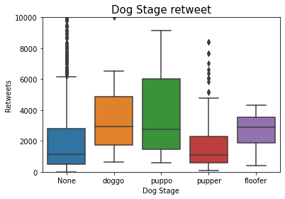

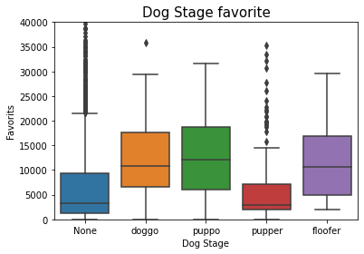

### Source distribution

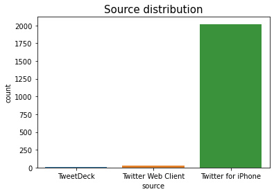

As the bar chart shows, the most common source was the Twitter for iPhone. that means that users use Twitter app on iPhone to upload pictures tweet, retweet, and favorite on WeRateDogs.

### Relation distribution between retweets and favorites

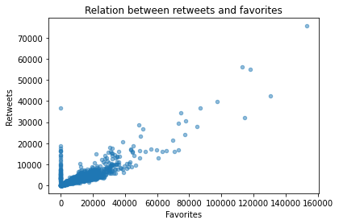

As the scatter plot shows, there is a positive correlation between retweets and favourites. That means that the highest a dog gets retweeted the higher it gets favorited.